# Astropy: Celestial Coordinates

## Documentation

For more information about the features presented below, you can read the [astropy.coordinates](http://docs.astropy.org/en/stable/coordinates/index.html) docs.

## Representing and converting coordinates

Astropy includes a framework to represent celestial coordinates and transform between them. Astropy includes common coordinate systems (ICRS, FK4, FK5, Galactic, and AltAz).

Creating coordinate objects is straightforward:

```python
from astropy.coordinates import SkyCoord
from astropy import units as u
```

```python
SkyCoord(ra=10.68458 * u.deg, dec=41.26917 * u.deg)
```

```
<SkyCoord (ICRS): (ra, dec) in deg
    (10.68458, 41.26917)>
```

```python
SkyCoord('00h42m44.3s +41d16m9s')
```

```
<SkyCoord (ICRS): (ra, dec) in deg
    (10.68458333, 41.26916667)>
```

The individual components of a coordinate are `Angle` objects, and their values are accessed using special attributes:

```python
c = SkyCoord('00h42m44.3s +41d16m9s')
```

```python
c.ra
```

$10^\circ41{}^\prime04.5{}^{\prime\prime}$

```python
c.ra.hour
```

```
0.7123055555555556
```

```python
c.ra.hms
```

```
hms_tuple(h=0.0, m=42.0, s=44.30000000000021)
```

```python
c.dec
```

$41^\circ16{}^\prime09{}^{\prime\prime}$

```python
c.dec.radian
```

```
0.7202828378876265
```

To convert to some other coordinate system, the easiest method is to use attribute-style access with short names for the built-in systems:

```python
c.galactic
```

```
<SkyCoord (Galactic): (l, b) in deg
    (121.17424437, -21.57288899)>
```

but explicit transformations via the `transform_to` method are also available:

```python
c.transform_to('galactic')
```

```
<SkyCoord (Galactic): (l, b) in deg
    (121.17424437, -21.57288899)>
```

The `astropy.coordinates` subpackage also provides a quick way to get coordinates for named objects (with an internet connection). The SkyCoord class has a method `from_name()`, that accepts a string and queries Sesame to retrieve coordinates for that object:

```python
c_eq = SkyCoord.from_name("M16")
c_eq
```

```
<SkyCoord (ICRS): (ra, dec) in deg
    (274.7, -13.8067)>
```

## Using arrays in coordinates

Numpy arrays can be used inside coordinate objects instead of scalar floating point values (this is much more efficient that creating one coordinate object for each source). The following example demonstrates how one can combine the `Table` class with coordinate objects (you can download the data from here).

```python
from astropy.table import Table
t = Table.read('data/2mass.tbl', format='ascii.ipac')
```

```python
t
```

<Table masked=True length=929>

| ra deg float64 | dec deg float64 | clon str384 | clat str416 | err_maj arcsec float64 | err_min arcsec float64 | err_ang deg int64 | designation str512 | j_m mag float64 | j_cmsig mag float64 | j_msigcom mag float64 | j_snr float64 | h_m mag float64 | h_cmsig mag float64 | h_msigcom mag float64 | h_snr float64 | k_m mag float64 | k_cmsig mag float64 | k_msigcom mag float64 | k_snr float64 | ph_qual str96 | rd_flg str96 | bl_flg str96 | cc_flg str96 | ndet str192 | gal_contam int64 | mp_flg int64 | dist float64 | angle float64 | j_h float64 | … |
| --- | --- | --- | --- | --- | --- | --- | --- | --- | --- | --- | --- | --- | --- | --- | --- | --- | --- | --- | --- | --- | --- | --- | --- | --- | --- | --- | --- | --- | --- | --- |
| 274.429506 | -13.870547 | 18h17m43.08s | -13d52m13.97s | 0.08 | 0.08 | 45 | 18174308-1352139 | 16.305 | 0.142 | 0.143 | 6.7 | 14.048 | 0.107 | 0.108 | 13.6 | 13.257 | 0.066 | 0.066 | 16.5 | CAA | 222 | 111 | 0ss | 066655 | 0 | 0 | 975.080151 | 256.448 | 2.257 | … |
| 274.423821 | -13.86974 | 18h17m41.72s | -13d52m11.06s | 0.06 | 0.06 | 90 | 18174171-1352110 | 14.802 | 0.058 | 0.059 | 26.7 | 12.635 | 0.059 | 0.06 | 50.1 | 11.768 | 0.045 | 0.046 | 65.2 | AAA | 222 | 111 | 0ss | 666666 | 0 | 0 | 993.752042 | 256.878 | 2.167 | … |
| 274.424587 | -13.739629 | 18h17m41.90s | -13d44m22.66s | 0.08 | 0.08 | 45 | 18174190-1344226 | 16.328 | -- | -- | -- | 14.345 | 0.059 | 0.06 | 10.4 | 13.405 | 0.046 | 0.047 | 14.4 | UAA | 022 | 011 | 0cc | 003666 | 0 | 0 | 995.726698 | 284.113 | -- | … |
| 274.433933 | -13.769502 | 18h17m44.14s | -13d46m10.21s | 0.08 | 0.08 | 45 | 18174414-1346102 | 16.281 | 0.098 | 0.099 | 6.8 | 14.057 | 0.035 | 0.036 | 13.5 | 12.956 | 0.032 | 0.033 | 21.8 | CAA | 222 | 111 | 000 | 065566 | 0 | 0 | 942.627418 | 278.252 | 2.224 | … |
| 274.437013 | -13.885698 | 18h17m44.88s | -13d53m08.51s | 0.09 | 0.09 | 45 | 18174488-1353085 | 15.171 | -- | -- | -- | 14.412 | 0.152 | 0.152 | 9.8 | 13.742 | 0.095 | 0.095 | 10.6 | UBA | 622 | 022 | 0cc | 005566 | 0 | 0 | 964.105389 | 252.93 | -- | … |
| 274.433996 | -13.752446 | 18h17m44.16s | -13d45m08.81s | 0.08 | 0.08 | 90 | 18174415-1345088 | 16.54 | -- | -- | -- | 14.519 | 0.083 | 0.083 | 8.8 | 13.604 | 0.043 | 0.044 | 12.0 | UBA | 022 | 011 | 0cc | 005666 | 0 | 0 | 953.230532 | 281.908 | -- | … |
| 274.418138 | -13.77215 | 18h17m40.35s | -13d46m19.74s | 0.08 | 0.08 | 90 | 18174035-1346197 | 17.98 | -- | -- | -- | 14.61 | 0.043 | 0.044 | 8.1 | 13.456 | 0.056 | 0.057 | 13.8 | UBA | 022 | 011 | 000 | 001645 | 0 | 0 | 996.047248 | 277.25 | -- | … |
| 274.433695 | -13.899049 | 18h17m44.09s | -13d53m56.58s | 0.06 | 0.06 | 90 | 18174408-1353565 | 13.011 | 0.021 | 0.024 | 139.0 | 10.917 | 0.02 | 0.021 | 243.8 | 10.013 | 0.017 | 0.019 | 328.3 | AAA | 222 | 111 | 000 | 666666 | 0 | 0 | 990.166399 | 250.466 | 2.094 | … |
| 274.425482 | -13.77149 | 18h17m42.12s | -13d46m17.36s | 0.08 | 0.08 | 135 | 18174211-1346173 | 16.086 | -- | -- | -- | 13.709 | 0.065 | 0.066 | 18.6 | 12.503 | 0.044 | 0.045 | 33.1 | UAA | 622 | 012 | 00c | 005555 | 0 | 0 | 970.896919 | 277.582 | -- | … |
| ... | ... | ... | ... | ... | ... | ... | ... | ... | ... | ... | ... | ... | ... | ... | ... | ... | ... | ... | ... | ... | ... | ... | ... | ... | ... | ... | ... | ... | ... | … |
| 274.81801 | -14.001245 | 18h19m16.32s | -14d00m04.48s | 0.18 | 0.16 | 1 | 18191632-1400044 | 16.24 | 0.113 | 0.113 | 5.6 | 15.531 | 0.164 | 0.164 | 2.5 | 15.252 | -- | -- | -- | CDU | 220 | 110 | 000 | 060600 | 0 | 0 | 809.817146 | 149.61 | 0.709 | … |
| 274.822709 | -14.037254 | 18h19m17.45s | -14d02m14.11s | 0.07 | 0.07 | 45 | 18191745-1402141 | 15.999 | 0.097 | 0.098 | 7.0 | 14.009 | 0.032 | 0.033 | 10.0 | 13.077 | 0.035 | 0.036 | 16.4 | CAA | 222 | 111 | 000 | 062656 | 0 | 0 | 931.339773 | 152.779 | 1.99 | … |
| 274.880758 | -13.99956 | 18h19m31.38s | -13d59m58.42s | 0.06 | 0.06 | 90 | 18193138-1359584 | 14.163 | 0.035 | 0.037 | 37.8 | 11.179 | 0.02 | 0.021 | 135.6 | 9.765 | 0.017 | 0.019 | 347.1 | AAA | 222 | 111 | 000 | 556666 | 0 | 0 | 935.512452 | 137.762 | 2.984 | … |
| 274.652526 | -14.055106 | 18h18m36.61s | -14d03m18.38s | 0.06 | 0.06 | 90 | 18183660-1403183 | 15.035 | 0.052 | 0.054 | 19.4 | 13.099 | 0.04 | 0.041 | 27.5 | 12.254 | 0.041 | 0.041 | 41.7 | AAA | 222 | 111 | c00 | 566666 | 0 | 0 | 908.109808 | 190.682 | 1.936 | … |
| 274.760586 | -13.999927 | 18h19m02.54s | -13d59m59.74s | 0.08 | 0.08 | 90 | 18190254-1359597 | 16.329 | 0.122 | 0.123 | 5.5 | 14.488 | 0.067 | 0.067 | 6.4 | 13.617 | 0.051 | 0.052 | 11.1 | CCA | 222 | 111 | 000 | 060616 | 0 | 0 | 724.557553 | 163.227 | 1.841 | … |
| 274.831132 | -14.020027 | 18h19m19.47s | -14d01m12.10s | 0.08 | 0.08 | 45 | 18191947-1401120 | 16.203 | -- | -- | -- | 13.238 | 0.02 | 0.021 | 20.4 | 12.016 | 0.023 | 0.024 | 43.6 | UAA | 022 | 011 | 000 | 006666 | 0 | 0 | 891.347132 | 149.27 | -- | … |
| 274.972435 | -13.760374 | 18h19m53.38s | -13d45m37.35s | 0.12 | 0.11 | 10 | 18195338-1345373 | 17.472 | -- | -- | -- | 16.755 | -- | -- | -- | 14.413 | 0.084 | 0.084 | 4.8 | UUD | 002 | 001 | 000 | 000006 | 0 | 0 | 964.828933 | 79.963 | -- | … |
| 274.870009 | -13.817775 | 18h19m28.80s | -13d49m03.99s | 0.08 | 0.08 | 45 | 18192880-1349039 | 16.933 | -- | -- | -- | 14.514 | 0.064 | 0.065 | 6.3 | 12.957 | 0.041 | 0.041 | 18.4 | UCA | 022 | 011 | 000 | 002666 | 0 | 0 | 592.998058 | 93.69 | -- | … |
| 274.735323 | -13.941575 | 18h18m56.48s | -13d56m29.67s | 0.14 | 0.14 | 45 | 18185647-1356296 | 16.643 | -- | -- | -- | 14.88 | -- | -- | -- | 14.291 | 0.116 | 0.117 | 6.0 | UUC | 002 | 001 | 000 | 000004 | 0 | 0 | 498.524438 | 165.968 | -- | … |
| 274.866294 | -13.841778 | 18h19m27.91s | -13d50m30.40s | 0.08 | 0.08 | 45 | 18192791-1350304 | 15.615 | -- | -- | -- | 13.911 | 0.075 | 0.075 | 10.9 | 12.765 | 0.134 | 0.134 | 21.9 | UAE | 022 | 011 | 0cc | 005545 | 0 | 0 | 591.97725 | 102.147 | -- | … |

```python
c = SkyCoord(t['ra'], t['dec'])
```

Note that we didn't have to give the units because these are contained in the table metadata!

```python
c.ra.degree[:10]
```

```
array([ 274.429506,  274.423821,  274.424587,  274.433933,  274.437013,
        274.433996,  274.418138,  274.433695,  274.425482,  274.433057])
```

We can also pass string columns:

```python
c = SkyCoord(t['clon'], t['clat'])
```

## Converting to/from AltAz

```python
import numpy as np
from astropy import units as u
from astropy.time import Time
from astropy.coordinates import SkyCoord, EarthLocation, AltAz
```

```python
m33 = SkyCoord.from_name('M33')
```

```python
bear_mountain = EarthLocation(lat=41.3*u.deg, lon=-74*u.deg, height=390*u.m)
utcoffset = -4 * u.hour  # Eastern Daylight Time
time = Time('2012-7-12 23:00:00') - utcoffset
```

```python
m33altaz = m33.transform_to(AltAz(obstime=time,location=bear_mountain))
```

```python
m33altaz.alt
```

$0^\circ07{}^\prime45.3475{}^{\prime\prime}$

```python
m33altaz.az
```

$47^\circ18{}^\prime29.2152{}^{\prime\prime}$

We now want to make a plot of the altitude vs time to plan observations

```python
midnight = Time('2012-7-13 00:00:00') - utcoffset
delta_midnight = np.linspace(-7, 7, 100) * u.hour
```

```python
m33altazs = m33.transform_to(AltAz(obstime=midnight+delta_midnight, location=bear_mountain))
```

We can now plot the results:

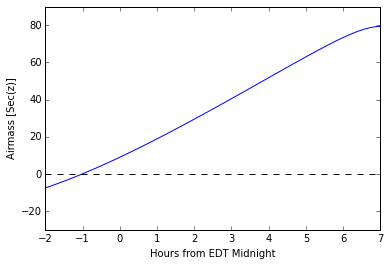

```python
%matplotlib inline
import matplotlib.pyplot as plt
plt.plot(delta_midnight, m33altazs.alt)
plt.xlim(-2, 7)
plt.ylim(-30, 90)
plt.axhline(0, color='k', ls='dashed')
plt.xlabel('Hours from EDT Midnight')
plt.ylabel('Airmass [Sec(z)]')
plt.show()
```

## Matching catalogs

Astropy includes functions that can help with catalog matching. Let's start from the 2MASS catalog used above and also use the WISE catalog for the same area of sky:

```python
t_2mass = Table.read('data/2mass.tbl', format='ascii.ipac')['ra', 'dec', 'j_m', 'h_m', 'k_m']
t_2mass
```

<Table masked=True length=929>

| ra deg float64 | dec deg float64 | j_m mag float64 | h_m mag float64 | k_m mag float64 |
| --- | --- | --- | --- | --- |
| 274.429506 | -13.870547 | 16.305 | 14.048 | 13.257 |
| 274.423821 | -13.86974 | 14.802 | 12.635 | 11.768 |
| 274.424587 | -13.739629 | 16.328 | 14.345 | 13.405 |
| 274.433933 | -13.769502 | 16.281 | 14.057 | 12.956 |
| 274.437013 | -13.885698 | 15.171 | 14.412 | 13.742 |
| 274.433996 | -13.752446 | 16.54 | 14.519 | 13.604 |
| 274.418138 | -13.77215 | 17.98 | 14.61 | 13.456 |
| 274.433695 | -13.899049 | 13.011 | 10.917 | 10.013 |
| 274.425482 | -13.77149 | 16.086 | 13.709 | 12.503 |
| ... | ... | ... | ... | ... |
| 274.81801 | -14.001245 | 16.24 | 15.531 | 15.252 |
| 274.822709 | -14.037254 | 15.999 | 14.009 | 13.077 |
| 274.880758 | -13.99956 | 14.163 | 11.179 | 9.765 |
| 274.652526 | -14.055106 | 15.035 | 13.099 | 12.254 |
| 274.760586 | -13.999927 | 16.329 | 14.488 | 13.617 |
| 274.831132 | -14.020027 | 16.203 | 13.238 | 12.016 |
| 274.972435 | -13.760374 | 17.472 | 16.755 | 14.413 |
| 274.870009 | -13.817775 | 16.933 | 14.514 | 12.957 |
| 274.735323 | -13.941575 | 16.643 | 14.88 | 14.291 |
| 274.866294 | -13.841778 | 15.615 | 13.911 | 12.765 |

```python
t_wise = Table.read('data/wise.tbl', format='ascii.ipac')['designation', 'ra', 'dec', 'w1mpro', 'w2mpro', 'w3mpro', 'w4mpro']
t_wise
```

<Table masked=True length=17816>

| designation str608 | ra deg float64 | dec deg float64 | w1mpro mag float64 | w2mpro mag float64 | w3mpro mag float64 | w4mpro mag float64 |
| --- | --- | --- | --- | --- | --- | --- |
| J181752.24-141213.2 | 274.4676959 | -14.2036914 | 10.009 | 10.047 | 10.197 | 8.298 |
| J181751.14-141210.7 | 274.463119 | -14.2029941 | 11.06 | 11.129 | 10.5 | 8.215 |
| J181751.89-141122.0 | 274.4662354 | -14.1894445 | 11.598 | 11.728 | 9.452 | 6.486 |
| J181752.41-141141.8 | 274.4684096 | -14.1949513 | 11.709 | 11.937 | 9.759 | 7.189 |
| J181750.20-141145.3 | 274.4592003 | -14.1959334 | 8.851 | 8.86 | 7.844 | 6.148 |
| J181750.22-141217.2 | 274.4592581 | -14.2047906 | 11.933 | 12.285 | 11.613 | 7.653 |
| J181751.35-141147.6 | 274.4639589 | -14.1965688 | 9.815 | 9.931 | 9.115 | 7.549 |
| J181756.19-141144.7 | 274.4841457 | -14.1957676 | 10.334 | 10.458 | 9.229 | 7.273 |
| J181756.80-141145.0 | 274.4866976 | -14.195861 | 9.938 | 10.002 | 10.2 | 7.299 |
| ... | ... | ... | ... | ... | ... | ... |
| J181823.85-141545.4 | 274.5994027 | -14.2626192 | 5.29 | 5.085 | 4.044 | 2.677 |
| J181823.55-141525.8 | 274.5981294 | -14.2571837 | 9.253 | 9.131 | 7.635 | 4.545 |
| J181821.52-141549.8 | 274.5896669 | -14.2638349 | 11.046 | 11.377 | 9.028 | 6.143 |
| J181825.74-141529.3 | 274.607255 | -14.2581409 | 11.134 | 11.212 | 9.685 | 6.36 |
| J181826.18-141546.2 | 274.6090842 | -14.2628371 | 8.692 | 8.834 | 8.86 | 6.675 |
| J181825.76-141609.2 | 274.6073677 | -14.2692411 | 11.401 | 11.34 | 9.26 | 6.217 |
| J181826.07-141624.5 | 274.6086441 | -14.2734739 | 8.526 | 8.634 | 8.756 | 6.527 |
| J181824.83-141619.9 | 274.603471 | -14.2721981 | 7.873 | 7.936 | 7.586 | 5.642 |
| J181823.90-141609.1 | 274.5996039 | -14.2692111 | 5.575 | 5.733 | 5.036 | 3.429 |
| J181829.04-141803.8 | 274.6210114 | -14.3010686 | 11.531 | 11.793 | 10.006 | 6.503 |

```python
c_2mass = SkyCoord(t_2mass['ra'], t_2mass['dec'])
c_wise = SkyCoord(t_wise['ra'], t_wise['dec'])
```

```python
idx_wise, idx_2mass, d2d, d3d = c_2mass.search_around_sky(c_wise, 5 * u.arcsec)
```

```python
t_2mass[idx_2mass]
```

<Table masked=True length=269>

| ra deg float64 | dec deg float64 | j_m mag float64 | h_m mag float64 | k_m mag float64 |
| --- | --- | --- | --- | --- |
| 274.624839 | -14.051597 | 16.03 | 13.823 | 13.145 |
| 274.6045 | -14.061802 | 13.031 | 11.234 | 10.251 |
| 274.605645 | -14.061247 | 15.099 | 13.279 | 12.46 |
| 274.623156 | -14.0676 | 15.038 | 13.245 | 12.551 |
| 274.797491 | -14.066624 | 13.965 | 13.019 | 12.61 |
| 274.798888 | -13.881427 | 14.398 | 12.738 | 11.863 |
| 274.779886 | -13.901997 | 16.904 | 13.905 | 12.479 |
| 274.763438 | -13.943701 | 17.379 | 14.327 | 12.757 |
| 274.755625 | -13.915264 | 15.847 | 12.606 | 11.033 |
| ... | ... | ... | ... | ... |
| 274.428059 | -13.769484 | 15.885 | 14.094 | 13.181 |
| 274.425482 | -13.77149 | 16.086 | 13.709 | 12.503 |
| 274.426632 | -13.770931 | 16.441 | 14.741 | 13.833 |
| 274.419872 | -13.765019 | 14.549 | 11.529 | 10.15 |
| 274.418138 | -13.77215 | 17.98 | 14.61 | 13.456 |
| 274.420732 | -13.772399 | 16.06 | 13.734 | 12.622 |
| 274.421593 | -13.77148 | 16.042 | 14.364 | 13.331 |
| 274.42386 | -13.865885 | 12.188 | 10.031 | 9.086 |
| 274.422162 | -13.859782 | 15.574 | 13.017 | 12.021 |
| 274.421415 | -13.858602 | 16.198 | 14.695 | 12.924 |

```python
t_wise[idx_wise]
```

<Table masked=True length=269>

| designation str608 | ra deg float64 | dec deg float64 | w1mpro mag float64 | w2mpro mag float64 | w3mpro mag float64 | w4mpro mag float64 |
| --- | --- | --- | --- | --- | --- | --- |
| J181829.96-140306.6 | 274.6248577 | -14.0518347 | 12.465 | 13.004 | 10.188 | 5.11 |
| J181825.09-140342.1 | 274.6045432 | -14.0617133 | 9.529 | 9.497 | 9.815 | 5.506 |
| J181825.09-140342.1 | 274.6045432 | -14.0617133 | 9.529 | 9.497 | 9.815 | 5.506 |
| J181829.48-140403.8 | 274.6228542 | -14.067728 | 11.852 | 12.424 | 10.286 | 6.192 |
| J181911.20-140355.8 | 274.7966965 | -14.0655162 | 10.736 | 10.857 | 11.196 | 7.671 |
| J181911.64-135256.2 | 274.7985357 | -13.8822786 | 10.711 | 10.96 | 7.908 | 4.735 |
| J181907.16-135406.2 | 274.7798452 | -13.9017291 | 11.235 | 12.894 | 8.652 | 5.447 |
| J181903.18-135637.2 | 274.7632695 | -13.9436841 | 10.771 | 11.327 | 5.488 | 3.366 |
| J181901.29-135454.8 | 274.7554103 | -13.915232 | 9.834 | 9.792 | 7.885 | 4.777 |
| ... | ... | ... | ... | ... | ... | ... |
| J181742.82-134611.6 | 274.4284175 | -13.769904 | 12.095 | 11.8 | 6.518 | 4.286 |
| J181742.14-134617.3 | 274.4256164 | -13.7714851 | 11.403 | 11.292 | 7.075 | 4.722 |
| J181742.14-134617.3 | 274.4256164 | -13.7714851 | 11.403 | 11.292 | 7.075 | 4.722 |
| J181740.77-134554.2 | 274.419875 | -13.7650572 | 9.376 | 9.176 | 9.198 | 4.708 |
| J181740.10-134616.4 | 274.4171127 | -13.7712265 | 12.447 | 12.832 | 9.178 | 6.375 |
| J181741.04-134619.8 | 274.4210011 | -13.7721765 | 11.569 | 11.655 | 8.606 | 6.116 |
| J181741.04-134619.8 | 274.4210011 | -13.7721765 | 11.569 | 11.655 | 8.606 | 6.116 |
| J181741.72-135157.2 | 274.4238584 | -13.8658986 | 8.519 | 8.606 | 7.844 | 4.485 |
| J181741.27-135135.1 | 274.4219657 | -13.8597573 | 11.331 | 11.292 | 9.897 | 4.96 |
| J181741.27-135135.1 | 274.4219657 | -13.8597573 | 11.331 | 11.292 | 9.897 | 4.96 |

```python
from astropy.table import hstack
```

```python
t_merged = hstack([t_2mass[idx_2mass], t_wise[idx_wise]])
```

[output not shown]

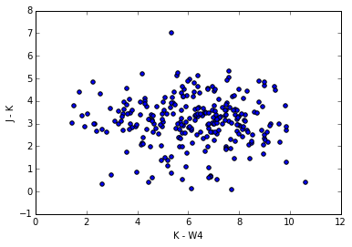

```python
plt.scatter(t_merged['k_m'] - t_merged['w4mpro'],
            t_merged['j_m'] - t_merged['k_m'])
plt.xlabel("K - W4")
plt.ylabel("J - K")
```

## Practical Exercises

### Level 1

Find the coordinates of the Crab Nebula in ICRS coordinates, and convert them to Galactic Coordinates.

### Level 2

Starting from this table in VO table format (this is the ROSAT all-sky catalog), read in the sources, use the RA and Dec columns to instantiate a coordinate object, then convert to Galactic coordinates. Make a plot of latitude versus longitude.

### Level 3

Once you have done Level 2, make an Aitoff projection map of the sources in Galactic coordinates. Then, try and match the ROSAT catalog with other catalogs that you have access to.